# Clase11-Copy1

### Dato curioso del día

- https://twitter.com/dansinker/status/1321227774246486022
- https://www.nature.com/articles/s41746-018-0045-1

[figure not shown]

### Modelado de temas

#### NLP - Analítica Estratégica de Datos

**Fundación Universitaria Konrad Lorenz**  
Docente: Viviana Márquez vivianam.penama@konradlorenz.edu.co  
Clase #11: 🎃Octubre 31, 2020

# Retroalimentación taller 7 & 8

### 🚵‍♀️ Entramos en la recta final...

[figure not shown]

### 🚵‍♀️ Entramos en la recta final...

[figure not shown]

### 🚵‍♀️ Entramos en la recta final...

[figure not shown]

### 🚀 Hoy veremos...

- Visualizaciones para proyectos de NLP 🚵‍♀️

[figure not shown]

### 🤔 ¿Por qué son importante las visualizaciones?

[figure not shown]

- Parte esencial de un profesional en datos
- Estamos un mundo lleno de datos
- Queremos ganar conocimiento (ENTENDER)
- Queremos hacer impacto (COMUNICAR)

### 🤔 ¿Por qué son importante las visualizaciones?

### Para ENTENDER nuestros datos

[figure not shown]

### 🤔 ¿Por qué son importante las visualizaciones?

### Para ENTENDER nuestros datos

[figure not shown]

### 🤔 ¿Por qué son importante las visualizaciones?

### Para COMUNICAR nuestros datos

[figure not shown]

### 🤔 ¿Por qué son importante las visualizaciones?

### Para COMUNICAR nuestros datos

[figure not shown]

### ⚙️ Herramientas más populares en el mercado para hacer visualizaciones

[figure not shown]

### ⚙️ Herramientas más populares en el mercado para hacer visualizaciones

[figure not shown]

### ⚙️ Herramientas más populares en el mercado para hacer visualizaciones

[figure not shown]

- Matplotlib
- Seaborn
- Plotly
- Bokeh
- Altair
- Geoplotlib

# 😉 Tips generales para las visualizaciones

Source: HubSpot + Visage

[figure not shown]

# 😉 Tips generales para las visualizaciones

- Piensa en la audiencia:
  - ¿Cómo van a crear tus datos objetivos realizables?
  - ¿Su público tiene el software necesario?
- Menos es más
  - En un mundo lleno de datos, queremos ENTENDER y COMUNICAR

### 🙋‍♀️ ¿Qué se dicen mis estudiantes?

[figure not shown]

| **Herramientas** | **Gráficas** |
| --- | --- |
| Jupyter Notebook | Mapas |
| Plotly & Dash | Mapas de calor |
| Flask | Barras |
| Tableau | Nube de palabras |
| PowerBI | Series de tiempo |
| Data Studio |  |

### 🙋‍♀️ ¿Qué se dicen mis estudiantes?

[figure not shown]

| **Herramientas** | **Gráficas** |
| --- | --- |
| ✅ Jupyter Notebook | ✅ Mapas |
| ✅ Plotly ❌ Dash | ✅ Mapas de calor |
| ❌ Flask | ✅ Barras |
| ✅ Tableau | ✅ Nube de palabras |
| ❌ PowerBI | ✅ Series de tiempo |
| ❌ [Data Studio](https://datastudio.google.com/u/0/navigation/reporting) |  |

# 1. Jupyter Notebook & GitHub Pages

- Jupyter Notebook te da la posibilidad de crear presentaciones con el plugging RISE
  - `pip install RISE`
  - `jupyter-nbextension install rise --py --sys-prefix`
  - `jupyter nbextension enable rise --py --sys-prefix`
- GitHub pages te da la opción de publicar presentaciones, páginas web, etc.
  - Instrucciones para subir presentaciones [aquí](https://medium.com/@alejatorresm/presentaciones-usando-jupyter-notebook-6cb20434fbe9) --- Ejemplo [aquí](https://alejandratm.github.io/Jupyter-Slides-Hola-Mundo/Presentacion-HW/Hello-litle-World.slides.html#/)
  - Ejemplo página web [aquí](http://vivianamarquez.com/) --- Plantilla [aquí](https://github.com/daattali/beautiful-jekyll)
- Visualizador de Notebooks `https://nbviewer.jupyter.org/github/` --- Ejemplo (1) [(2)](https://nbviewer.jupyter.org/github/vivianamarquez/NLP_Analitica_Estategica_Datos/blob/master/Clases/Clase10/Clase10.ipynb)

### Presentaciones con Jupyter Notebook

1. Instalar RISE

[figure not shown]

### Presentaciones con Jupyter Notebook

1. Botón de presentación debe aparecer

[figure not shown]

2. Seleccionar Markdown

[figure not shown]

### Presentaciones con Jupyter Notebook

1. Modo presentación

[figure not shown]

### Presentaciones con Jupyter Notebook

1. Exportar

[figure not shown]

2. Los Jupyter Notebooks pueden ser usados para otros lenguajes de programación

#### Carguemos los datos con los que vamos a trabajar

```python
import pandas as pd

data = pd.read_csv('archivos/hween_clean.csv')
data.head()
```

|  | texto | fecha | ciudad | departamento | lat | lon |
| --- | --- | --- | --- | --- | --- | --- |
| 0 | ¿Desparchado porque mañana no podrás salir a p... | 2020-10-31 00:16:27 | Bogotá | Cundinamarca | 4.649178 | -74.062827 |
| 1 | Participa en nuestro concurso de disfraces y l... | 2020-10-31 00:15:34 | Bogotá | Cundinamarca | 4.649178 | -74.062827 |
| 2 | MEGA-ESPECIAL Halloween 🎃 (Parte 53). Yo veo u... | 2020-10-31 00:13:59 | Bogotá | Cundinamarca | 4.649178 | -74.062827 |
| 3 | Un mensaje especial para los padres de familia... | 2020-10-31 00:11:46 | Bogotá | Cundinamarca | 4.649178 | -74.062827 |
| 4 | Luna azul con halloween 🤪👻🤔 | 2020-10-31 00:10:04 | Bogotá | Cundinamarca | 4.649178 | -74.062827 |

# 2. Nube de palabras

`pip install wordcloud`

```python
import numpy as np

from wordcloud import WordCloud
from wordcloud import ImageColorGenerator

from nltk.corpus import stopwords
stopwords = stopwords.words('spanish')

import matplotlib.pyplot as plt
import PIL.Image
from IPython.display import display
```

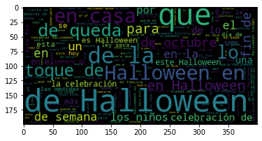

```python
palabras = data.texto.str.cat(sep=" ")
wordcloud = WordCloud().generate(palabras)

plt.imshow(wordcloud)
plt.show()
```

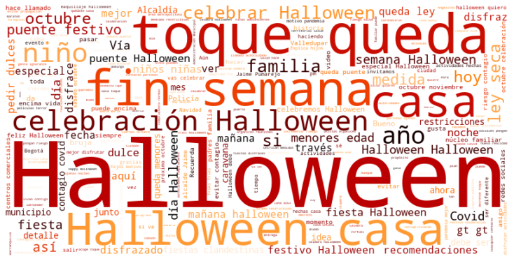

```python
# Más en https://www.datacamp.com/community/tutorials/wordcloud-python
palabras = data.texto.str.cat(sep=' ')

wordcloud = WordCloud(width=800, height=400,
                     max_font_size=150, max_words=250,
                     background_color='white', colormap='gist_heat',
                     stopwords=stopwords).generate(palabras) # https://matplotlib.org/3.1.0/tutorials/colors/colormaps.html

plt.figure(figsize=(10,8))
plt.imshow(wordcloud, interpolation='bilinear')
plt.axis("off")
plt.tight_layout(pad=0)
plt.show()
```

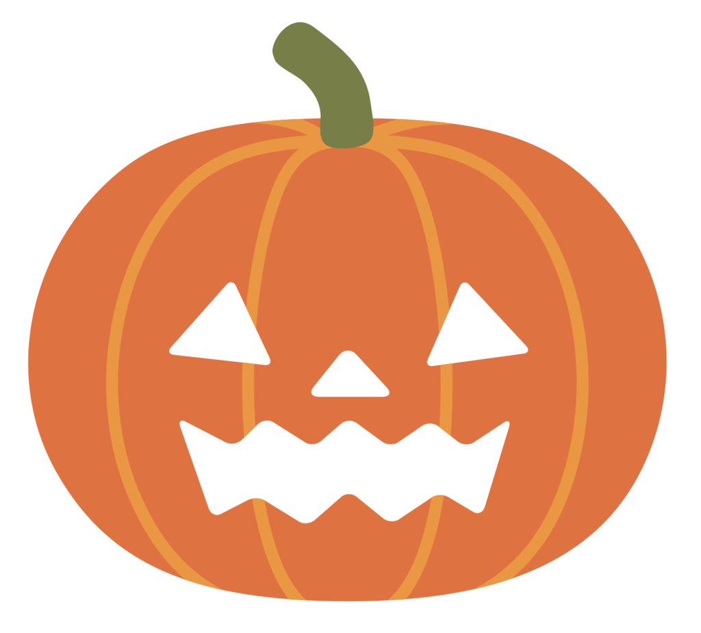

```python
calabaza = PIL.Image.open("img/calabaza2.png")
display(calabaza)
```

```python
mask = np.array(calabaza)
mask
```

[output not shown]

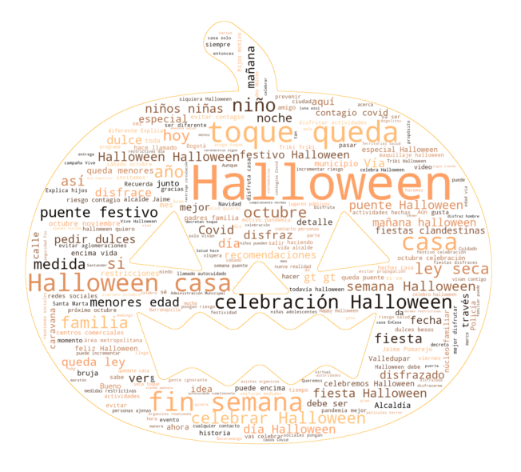

```python
# Más en https://www.datacamp.com/community/tutorials/wordcloud-python
palabras = data.texto.str.cat(sep=' ')

wordcloud = WordCloud(width=800, height=400,
                     max_font_size=150, max_words=250,
                     background_color='white', colormap='copper_r',
                     stopwords=stopwords,
                     mask=mask, contour_width=0.5, contour_color='orange').generate(palabras) # https://matplotlib.org/3.1.0/tutorials/colors/colormaps.html

wordcloud.to_file("calabaza.png")

plt.figure(figsize=(10,8))
plt.imshow(wordcloud, interpolation='bilinear')
plt.axis("off")
plt.tight_layout(pad=0)
plt.show()
```

# 3. Tableau

Link de descarga: https://public.tableau.com/en-us/s/download

- Programa para crear tableros (dashboards) interactivos
- Tiene varios productos:
  - Tableau Desktop (Profesional)
  - Tableau Server
  - Tableau Prep (flujo de datos)
  - Tableau Public (versión gratis) [Link](https://public.tableau.com/profile/viviana.m.rquez#!/?newProfile=&activeTab=0)
- Se puede conectar Python y R a Tableau [Link1](https://vivianamarquez.medium.com/python-tableau-desktop-101-b1281d9f7404) [Link2](https://vivianamarquez.medium.com/tableau-prep-python-101-c6a2b5292233)

#### Gráficos que vamos a hacer:

- Nube de palabras
- Mapa de árbol
- Mapa

#### Vamos a preparar los datos

```python
# nube de palabras & mapa de árbol
ciudad1 = 'Barranquilla'
ciudad2 = 'Medellín'

data1 = data[data.ciudad==ciudad1]
data2 = data[data.ciudad==ciudad2]

palabras1 = data1.texto.str.cat(sep=" ")
palabras2 = data2.texto.str.cat(sep=" ")

wordcloud1 = WordCloud(stopwords = stopwords).generate(palabras1).words_
wordcloud2 = WordCloud(stopwords = stopwords).generate(palabras2).words_

temp1 = pd.DataFrame.from_dict(wordcloud1, orient='index').reset_index()
temp1.columns = ['palabra', 'cnt']
temp1['ciudad'] = ciudad1

temp2 = pd.DataFrame.from_dict(wordcloud2, orient='index').reset_index()
temp2.columns = ['palabra', 'cnt']
temp2['ciudad'] = ciudad2

data_nube = pd.concat([temp1, temp2])

data_nube.to_csv('nube.csv', index=False)
```

```python
# mapa
data['contador_palabras'] = data.texto.apply(lambda valor: len(valor.split()))
data[['ciudad', 'lat', 'lon', 'contador_palabras']].to_csv("mapa.csv")
```

# Resultado: https://public.tableau.com/profile/viviana.m.rquez#!/vizhome/HalloweenNLP/Dashboard1?publish=yes

# 4. La trifecta: Plotly, Dash y Flask

- **Plotly**: Herramienta de visualización interactiva. Funciona con Python, R, Julia, etc. [Recurso](https://plotly.com/python/plotly-fundamentals/)
- **Dash**: Entorno de trabajo para construir aplicaciones web (usa Flask y Plotly) [Rescurso](https://www.datacamp.com/community/tutorials/learn-build-dash-python). [Ejemplo](https://msds2019.herokuapp.com/)
- **Flask**: Entorno de trabajo para construir aplicaciones web para Python [Recurso](https://flask.palletsprojects.com/en/1.1.x/tutorial/)

`pip install plotly==4.12.0`

# ¡Tiempo de taller!

[figure not shown]

**Fecha de entrega:** Noviembre 7, 2020. (Antes del inicio de la próxima clase)

# Evaluación!!! Me lo prometieron!

# Nos vemos a las 10:30 a.m. para GitHub y Nube de Palabras

[figure not shown]

# Evaluación docente

13 de octubre al 7 de noviembre

# http://virtual2.konradlorenz.edu.co/login/index.php

Cualquier duda o requerimiento puede ser remitido al correo evaluacion.docente@konradlorenz.edu.co

[figure not shown]

### Próxima clase: NLP y Redes Sociales